# Day 3: Networks

# Introduction

In this set of exercises, we will go through creating a network in `igraph` visualising it using `ggplot2`, setting node attributes and plotting some features of the network.

First, we read in the network data - the edge list is in the form of a .txt file, so we use `read.table` instead of `read.csv`.

After reading the data, we drop the repeated edges from the edge list using distinct in `dplyr`. Then make sure the ordering of the nodes from the graph vertices matches the edge list using match.

Finally, assign the node attributes using the `$` on `V(school_graph)`.

```r
# Set working directory here if needed!
library(dagitty)
library(dplyr)
library(ggdag)
library(ggraph)
library(ggplot2)
library(igraph)
library(tidygraph)

# Read in network data
nodes <- read.csv("../../data/school_nodelist.csv")
edges <- read.table("../../data/school_edgelist.txt")

# Drop repeated edges
edges <- edges[, 1:2] %>% distinct(V1, V2)

# Fix node ordering
school_graph <- graph_from_edgelist(as.matrix(edges) + 1)
reorder <- match(nodes$ID, V(school_graph))
nodes <- arrange(nodes, reorder)

# Assign the node attributes using the $ on V(school_graph)
V(school_graph)$role <- nodes$Role
```

# Exercise 1: summary statistics

Now look for some summary statistics about the data - how many individuals are there? How many roles, and which are the different roles? How many individuals of each role are there?

```r
# How many different kinds of roles are there in the network
unique(V(school_graph)$role)
```

```
## [1] "teacher" "student" "staff"   "other"
```

```r
# How many people are there in each role?
nrow(nodes %>% filter(Role == "staff"))
```

```
## [1] 55
```

# Exercise 2: edge case

Currently, it’s a bit hard to visualise the full graph, because there are two many nodes.

If we have set the node attributes previously for our graph, these attributes will carry over to the subgraph!

Plot the resulting subgraph. Colour the nodes according to the role that each of them plays.

use `as.factor` to convert the roles to factors, and then assign the colors as node attributes using `V(graph)$color`

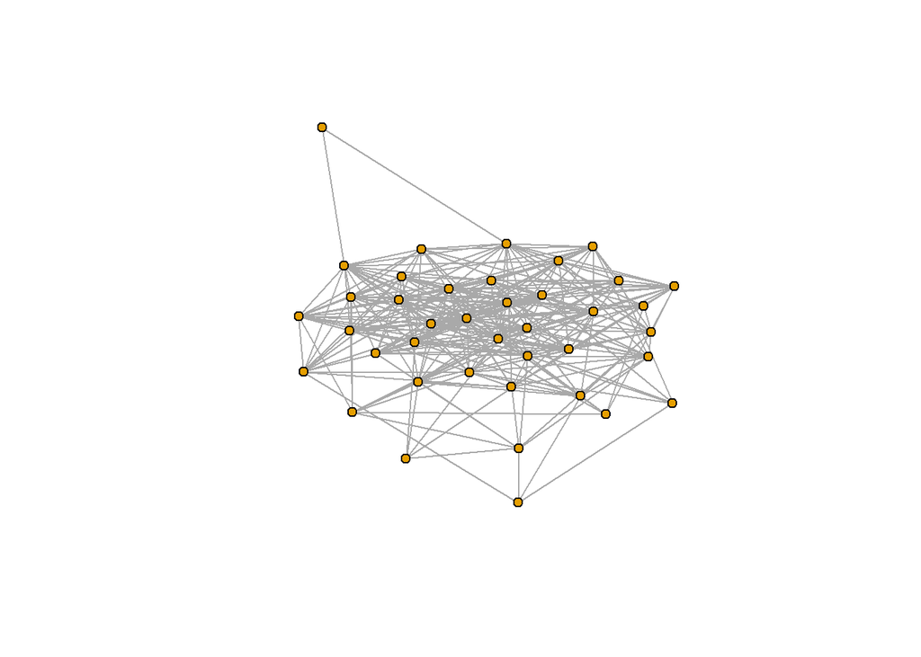

```r
# Randomly subsample the nodes from the full graph - set the seed to get the
# same nodes each time!
set.seed(123)
sample_size <- 40
subgraph_nodes <- sample(V(school_graph), sample_size)

# Create subgraph using these nodes
school_subgraph <- as.undirected(subgraph(school_graph, subgraph_nodes))

# Customise layout
layout <- layout_nicely(school_subgraph)

plot(school_subgraph,
  vertex.label = NA, vertex.size = 5, edge.size = 2,
  layout = layout
)
```

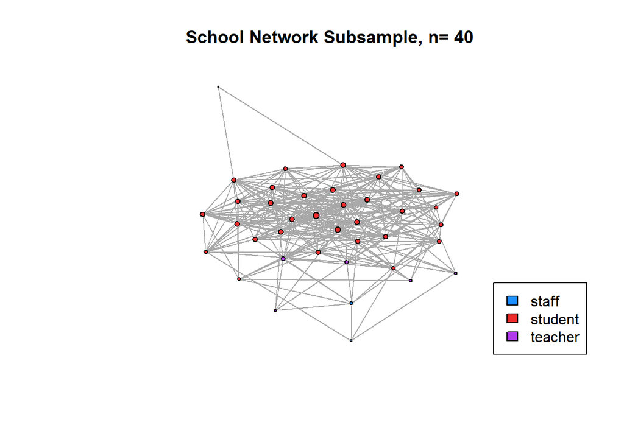

```r
# Get the corresponding subgraph node attributes, i.e.
# subgraph_node_attrs <- nodes %>% filter(ID %in% subgraph_nodes) %>% select(ID, Role)

# Set the colours of the roles
colors <- c("dodgerblue", "firebrick2", "darkorchid2", "gold2")
V(school_subgraph)$color <- colors[as.factor(V(school_subgraph)$role)]


labels <- c("other", "staff", "student", "teacher")

# Get degrees for plotting
degrees <- degree(school_subgraph)
# Plot!
plot(school_subgraph, layout = layout, vertex.label = NA, vertex.size = sqrt(degrees))
# Set legend to show how colours correspond to roles.
legend("bottomright", legend = levels(as.factor(V(school_subgraph)$role)), fill = colors)
title(paste("School Network Subsample, n=", as.character(sample_size)))
```

# Exercise 3: network statistics

When we sample the vertices, we are excluding full data about the network.

As we discussed in lectures, one way to visualise information about the whole graph is to show the degree distribution.

Plot the degree distribution for the whole graph. Do this once for every node, and then repeat with the distributions for each separate role. Do the degree distributions look significantly different for the different roles?

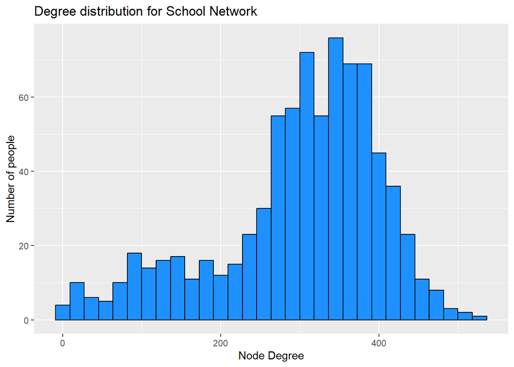

```r
nodes$degree <- degree(school_graph)

degree_dist <- ggplot(nodes, aes(x = degree)) +
  geom_histogram(fill = "dodgerblue", color = "black") +
  labs(
    x = "Node Degree",
    y = "Number of people"
  ) +
  ggtitle("Degree distribution for School Network")
degree_dist
```

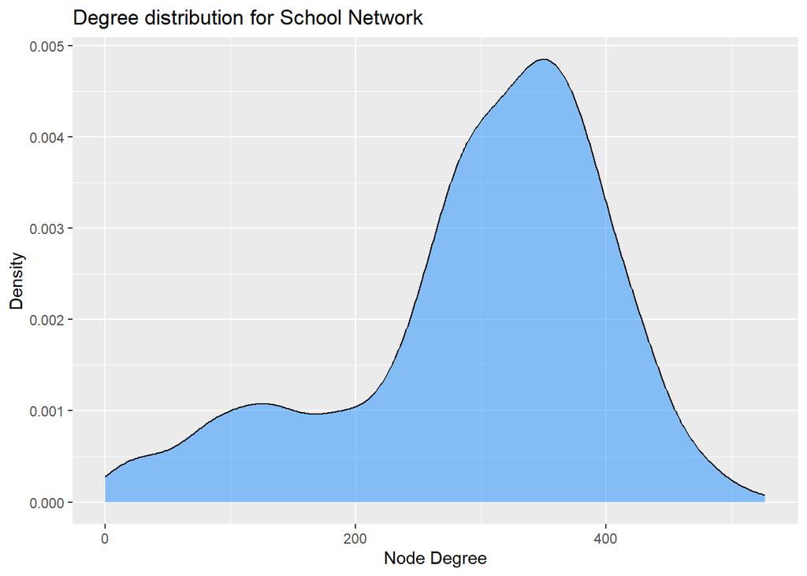

```r
degree_density <- ggplot(nodes, aes(x = degree)) +
  geom_density(fill = "dodgerblue", color = "black", alpha = 0.5) +
  labs(
    x = "Node Degree",
    y = "Density"
  ) +
  ggtitle("Degree distribution for School Network")
degree_density
```

Now show the distributions separated by roles. Compare the histogram with the density plot - which do you prefer?

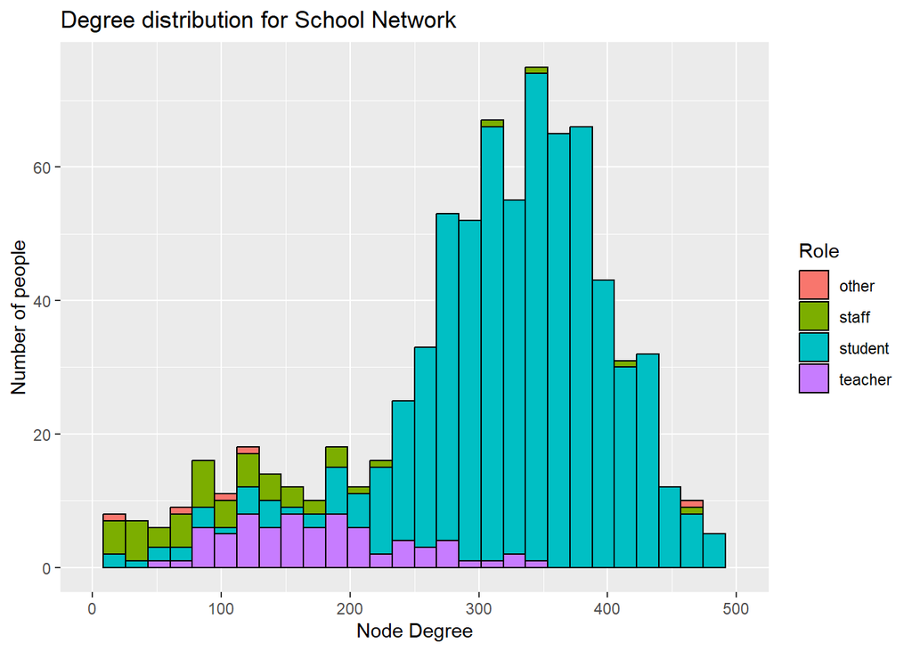

```r
degree_dist_role <- ggplot(nodes, aes(x = degree, fill = Role)) +
  geom_histogram(color = "black") +
  labs(
    x = "Node Degree",
    y = "Number of people"
  ) +
  ggtitle("Degree distribution for School Network") +
  xlim(0, 500)
show(degree_dist_role)
```

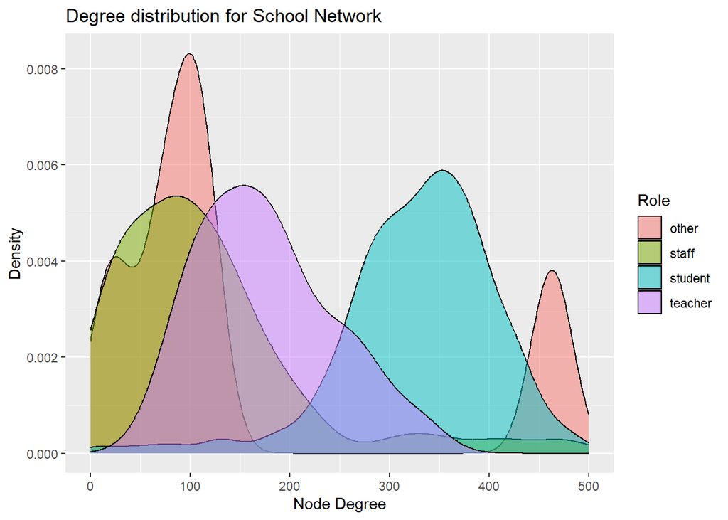

```r
degree_density_role <- ggplot(nodes, aes(x = degree, fill = Role)) +
  geom_density(color = "black", alpha = 0.5) +
  labs(
    x = "Node Degree",
    y = "Density"
  ) +
  ggtitle("Degree distribution for School Network") +
  xlim(0, 500)
show(degree_density_role)
```

# Exercise 4: Remember the subgraph?

Let’s also check whether the subgraph is a good representation of the full graph in terms of degree distribution. Plot the degree distributions for the two graphs in a single plot.

Do they look similar?

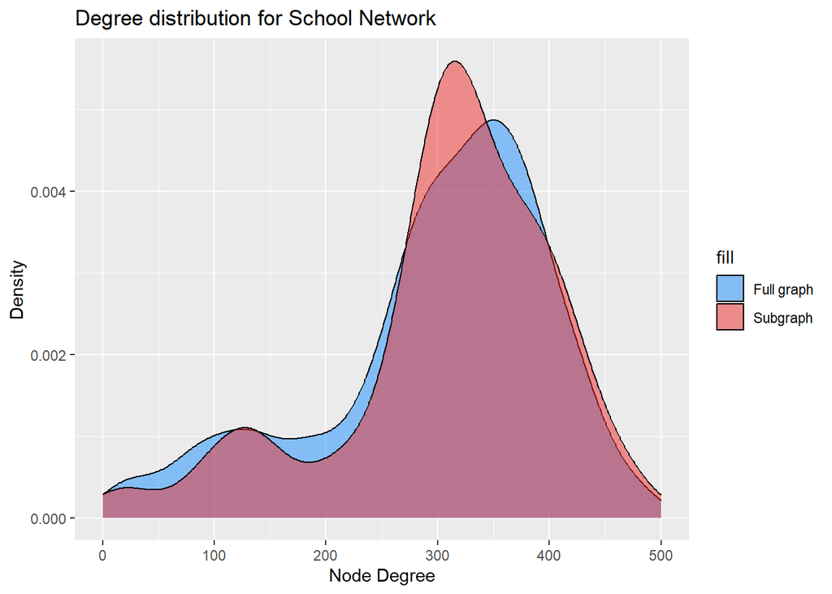

```r
subgraph_node_degrees <- nodes %>%
  filter(ID %in% subgraph_nodes) %>%
  select(ID, degree)

color_manual <- c("Full graph" = "dodgerblue", "Subgraph" = "firebrick2")

subgraph_degree_comparison <- ggplot(nodes, aes(x = degree, fill = "Full graph")) +
  geom_density(alpha = 0.5, color = "black") +
  geom_density(
    data = subgraph_node_degrees, aes(x = degree, fill = "Subgraph"),
    color = "black", alpha = 0.5
  ) +
  labs(
    x = "Node Degree",
    y = "Density"
  ) +
  ggtitle("Degree distribution for School Network") +
  xlim(0, 500) +
  scale_fill_manual(values = color_manual)

subgraph_degree_comparison
```

# Exercise 5 (extension): node to self: there are more network libraries

Extension: Have a go at converting the school subgraph into a `tidygraph` object. Use the function as_tbl_graph to convert an igraph object to a `tidygraph`, and then use ggraph to plot.

Experiment with different ways of displaying the nodes and edges, as well as the layout and colors of the vertices. Do you prefer this way of visualising networks compared with `igraph`?

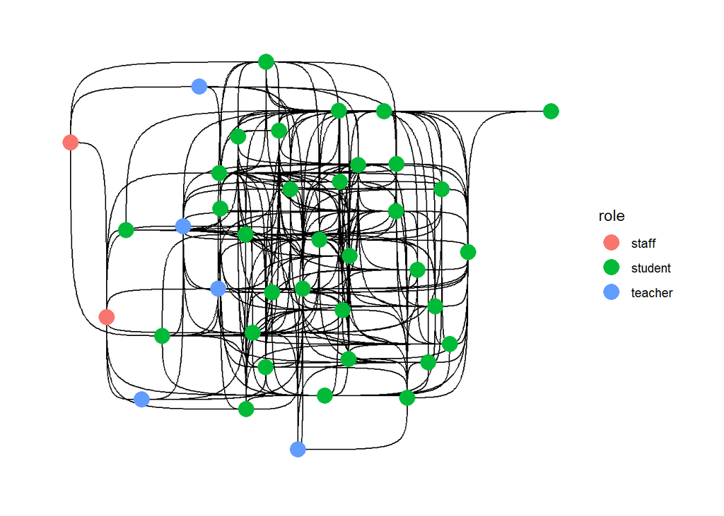

```r
subgraph_nodes_df <- nodes %>% filter(ID %in% subgraph_nodes)

# Define tidygraph object
new_graph <- as_tbl_graph(school_subgraph,
  node_labels = subgraph_nodes_df$ID,
  role = subgraph_nodes_df$Role,
  degrees = subgraph_nodes_df$degree
)

# Play around here with different geom_edge and geom_node styles
g_plot <- ggraph(new_graph) +
  geom_edge_bend(show.legend = FALSE) +
  geom_node_point(aes(color = role), show.legend = TRUE, size = 5) +
  theme_graph(background = "white")
show(g_plot)
```

# Exercise 6: DAG-nificent

Let’s look at creating a DAG in `dagitty`: Create a simple DAG with 5 variables, called A, B, C, D and E, and make up some associations between the variables.

If you prefer, you could make a DAG from your real research!

If you want to, you can also try playing around with the features in `ggdag` - this requires you to make a `dagify()` object instead. See this tutorial for some ideas of how to start https://cloud.r-project.org/web/packages/ggdag/vignettes/intro-to-ggdag.html and the kinds of functions available.

```r
# Create a DAG using dagitty
dag_example <- dagitty("dag{
                        A
                        B
                        C
                        D
                        E
                        A -> B
                        A -> C
                        B -> D
                        B -> E
                        C -> D
                        D -> E

                        }")

# Check that it is acyclic!! Then plot:
print(isAcyclic(dag_example))
```

```
## [1] TRUE
```

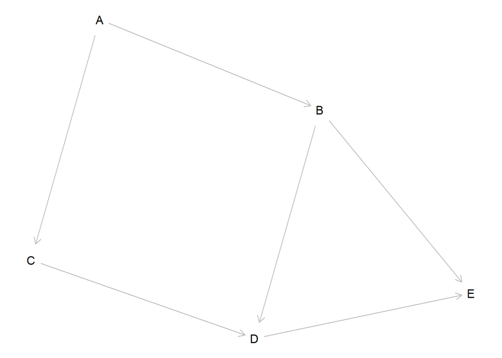

```r
plot(dag_example)
```

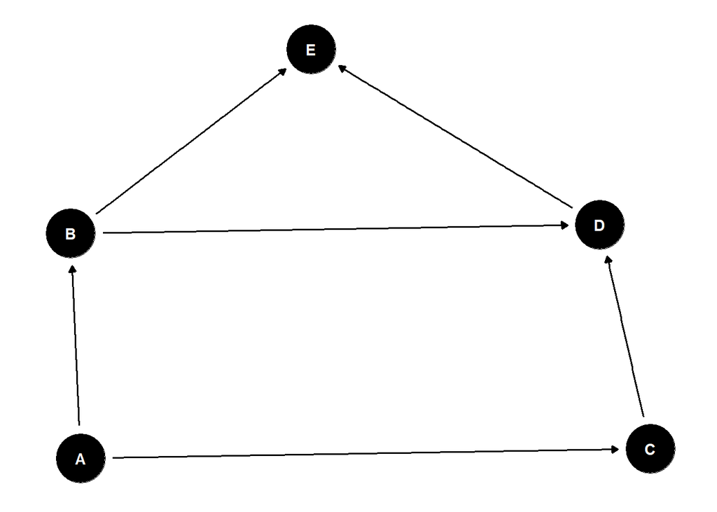

```r
# Create the same DAG using dagify

ggdag_example <- dagify(E ~ B + D,
  D ~ B + C,
  C ~ A,
  B ~ A,
  exposure = "A",
  outcome = "E"
) %>% tidy_dagitty()



# Create some nice ggdag plots
ggdag(ggdag_example) +
  theme_dag()
```

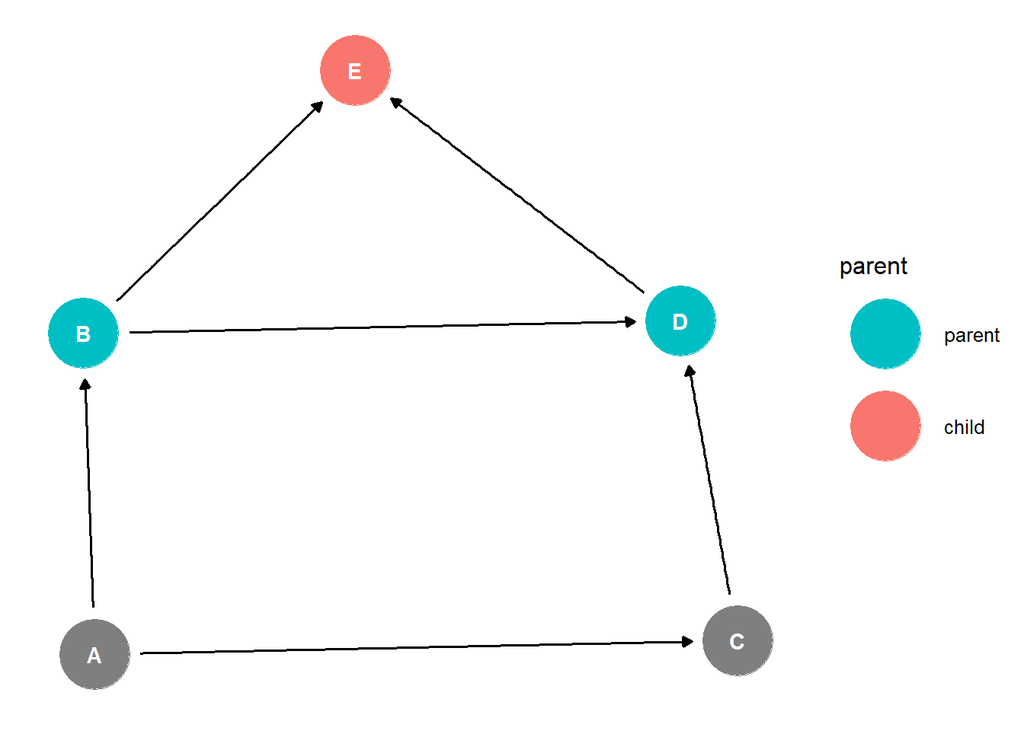

```r
ggdag_parents(ggdag_example, "E") +
  theme_dag()
```

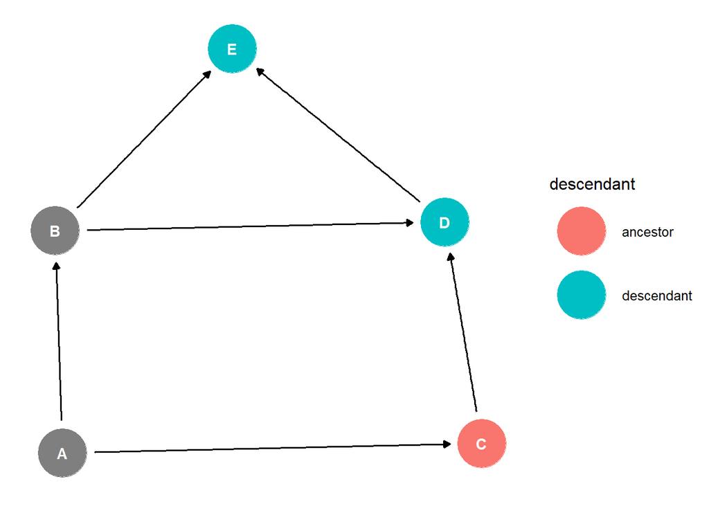

```r
ggdag_descendants(ggdag_example, "C") +
  theme_dag()
```